# Reproducible Research: Peer Assessment 1

## Loading and preprocessing the data

1. Load the data

```r
# create a temporary directory
td = tempdir()
# get the name of the first file in the zip archive
fname = unzip("activity.zip", list=TRUE)$Name
# unzip the file to the temporary directory
unzip("activity.zip", files=fname, exdir=td, overwrite=TRUE)
# fpath is the full path to the extracted file
fpath = file.path(td, fname)
# read the file
d = read.csv(fpath, header=TRUE, row.names=NULL,
             stringsAsFactors=FALSE)
```

1. Process/transform the data (if necessary) into a format suitable for your analysis

```r
d$date <- as.Date(d$date)
```

## What is mean total number of steps taken per day?

1. Make a histogram of the total number of steps taken each day

```r
# function to sum step in a Date
date_factor <- as.factor(d$date)
step_per_day <- tapply(d$steps,date_factor,sum,na.rm =T)
head(step_per_day)
```

```
## 2012-10-01 2012-10-02 2012-10-03 2012-10-04 2012-10-05 2012-10-06
##          0        126      11352      12116      13294      15420
```

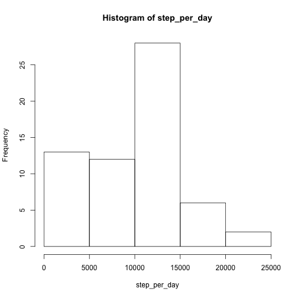

```r
hist(step_per_day)
```

2. Calculate and report the mean and median total number of steps taken per day

```r
# mean and median total number of steps taken per day
# step_per_day<-tapply(d_clean$steps,as.factor(d_clean$date),sum)
mean(step_per_day) #[1] 9354.23
```

```
## [1] 9354.23
```

```r
# median total number of steps taken per day
median(step_per_day) #[1] 10395
```

```
## [1] 10395
```

## What is the average daily activity pattern?

1. Make a time series plot (i.e. type = “l”) of the 5-minute interval (x-axis) and the average number of steps taken, averaged across all days (y-axis)

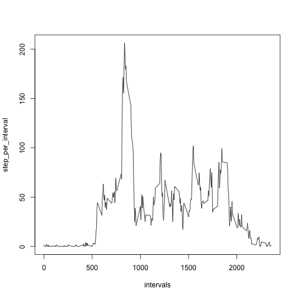

```r
# replace NA by 0
d_clean <- na.omit(d)
step_per_interval<-tapply(d_clean$steps,as.factor(d_clean$interval),mean)
intervals <-levels(as.factor(d_clean$interval))
plot(intervals,step_per_interval,type="l")
```

2.Which 5-minute interval, on average across all the days in the dataset, contains the maximum number of steps?

```r
intervals[max.col(t(step_per_interval))]
```

```
## [1] "835"
```

## Imputing missing values

Note that there are a number of days/intervals where there are missing values (coded as NA). The presence of missing days may introduce bias into some calculations or summaries of the data.

1. Calculate and report the total number of missing values in the dataset (i.e. the total number of rows with NAs)

```r
na_idx <- is.na(d)
sum(na_idx)
```

```
## [1] 2304
```

1. Devise a strategy for filling in all of the missing values in the dataset. The strategy does not need to be sophisticated. For example, you could use the mean/median for that day, or the mean for that 5-minute interval, etc.
2. Create a new dataset that is equal to the original dataset but with the missing data filled in.

```r
d_clean2 <- d
# replace na by the mean for that 5-minute interval
d_clean2[na_idx[,"steps"],"steps"]<-step_per_interval[as.character(d_clean2[na_idx[,"steps"],"interval"])]
d_clean2$steps[1:5]==step_per_interval[1:5]
```

```
##    0    5   10   15   20
## TRUE TRUE TRUE TRUE TRUE
```

```r
step_per_day2 <- tapply(d_clean2$steps,date_factor,sum)
head(step_per_day2)
```

```
## 2012-10-01 2012-10-02 2012-10-03 2012-10-04 2012-10-05 2012-10-06
##   10766.19     126.00   11352.00   12116.00   13294.00   15420.00
```

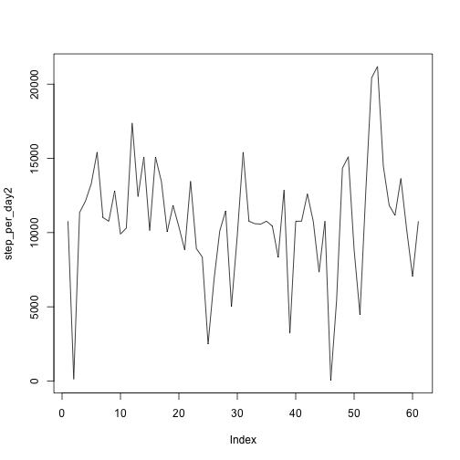

```r
plot(step_per_day2,type="l")
```

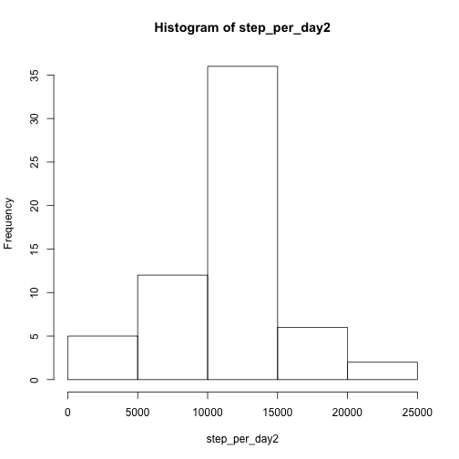

```r
# histogram
hist(step_per_day2)
```

## Are there differences in activity patterns between weekdays and weekends?

For this part the weekdays() function may be of some help here. Use the dataset with the filled-in missing values for this part.

1. Create a new factor variable in the dataset with two levels – “weekday” and “weekend” indicating whether a given date is a weekday or weekend day.

```r
weekend_factor<-weekdays(as.Date(levels(date_factor)))
weekend_idx<-weekend_factor %in% c("Saturday","Sunday")
weekend_factor[weekend_idx]<-"weekend"
weekend_factor[!weekend_idx]<-"weekday"
weekend_factor<-as.factor(weekend_factor)
weekend_factor
```

```
##  [1] weekday weekday weekday weekday weekday weekend weekend weekday
##  [9] weekday weekday weekday weekday weekend weekend weekday weekday
## [17] weekday weekday weekday weekend weekend weekday weekday weekday
## [25] weekday weekday weekend weekend weekday weekday weekday weekday
## [33] weekday weekend weekend weekday weekday weekday weekday weekday
## [41] weekend weekend weekday weekday weekday weekday weekday weekend
## [49] weekend weekday weekday weekday weekday weekday weekend weekend
## [57] weekday weekday weekday weekday weekday
## Levels: weekday weekend
```

```r
library("lattice")
head(d_clean2)
```

```
##       steps       date interval
## 1 1.7169811 2012-10-01        0
## 2 0.3396226 2012-10-01        5
## 3 0.1320755 2012-10-01       10
## 4 0.1509434 2012-10-01       15
## 5 0.0754717 2012-10-01       20
## 6 2.0943396 2012-10-01       25
```

```r
# add weekend factor
d_clean2$weekendfactor = as.factor(sapply(1:61,
                                          FUN=function(x)
                                            {rep(weekend_factor[x],288)}
                                          )[1:17568])
d_clean2$interval <- as.factor(d_clean2$interval)
head(d_clean2)
```

```
##       steps       date interval weekendfactor
## 1 1.7169811 2012-10-01        0       weekday
## 2 0.3396226 2012-10-01        5       weekday
## 3 0.1320755 2012-10-01       10       weekday
## 4 0.1509434 2012-10-01       15       weekday
## 5 0.0754717 2012-10-01       20       weekday
## 6 2.0943396 2012-10-01       25       weekday
```

```r
str(d_clean2)
```

```
## 'data.frame':    17568 obs. of  4 variables:
##  $ steps        : num  1.717 0.3396 0.1321 0.1509 0.0755 ...
##  $ date         : Date, format: "2012-10-01" "2012-10-01" ...
##  $ interval     : Factor w/ 288 levels "0","5","10","15",..: 1 2 3 4 5 6 7 8 9 10 ...
##  $ weekendfactor: Factor w/ 2 levels "weekday","weekend": 1 1 1 1 1 1 1 1 1 1 ...
```

```r
# use reshape lib to calculate the grouped average
#install.packages("reshape")
library(reshape)
d_clean3 <- cast(melt(d_clean2,id=c("weekendfactor","interval")),weekendfactor~interval,mean)
dim(d_clean3)
```

```
## [1]   2 289
```

```r
head(d_clean3)
```

[output not shown]

[output cut: 93 more lines]

```r
d_clean4 <-data.frame(weekendf=as.factor(c(rep("weekday",288),rep("weekend",288))),
                     intervalf=as.numeric(rep(names(step_per_interval),2)),
                     steps=as.numeric(cbind(d_clean3[1,2:289],d_clean3[2,2:289])))
head(d_clean4)
```

```
##   weekendf intervalf    steps
## 1  weekday         0 7823.126
## 2  weekday         5 7822.223
## 3  weekday        10 7822.087
## 4  weekday        15 7822.099
## 5  weekday        20 7822.049
## 6  weekday        25 7822.795
```

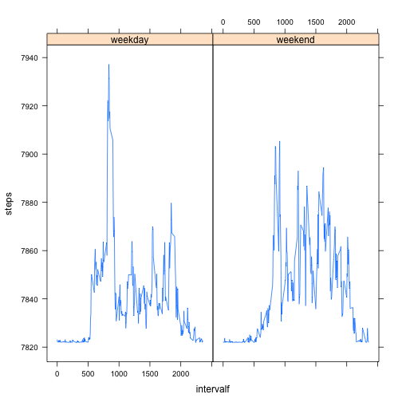

```r
xyplot(steps ~ intervalf|weekendf,data=d_clean4,type="l")
```